# Reproducible Research Project 1

John Cleveland

May 9, 2016

## Loading and preprocessing the data

Show any code that is needed to

##### 1. Load the data (i.e. `read.csv()`)

##### 2. Process/transform the data (if necessary) into a format suitable for your analysis

```r
library(ggplot2)
library(scales)
library(Hmisc)
```

```r
activity_data <- read.csv('activity.csv')
```

## What is mean total number of steps taken per day?

```r
steps_per_day <- tapply(activity_data$steps, activity_data$date, sum, na.rm=TRUE)
```

##### 1. Make a histogram of the total number of steps taken each day

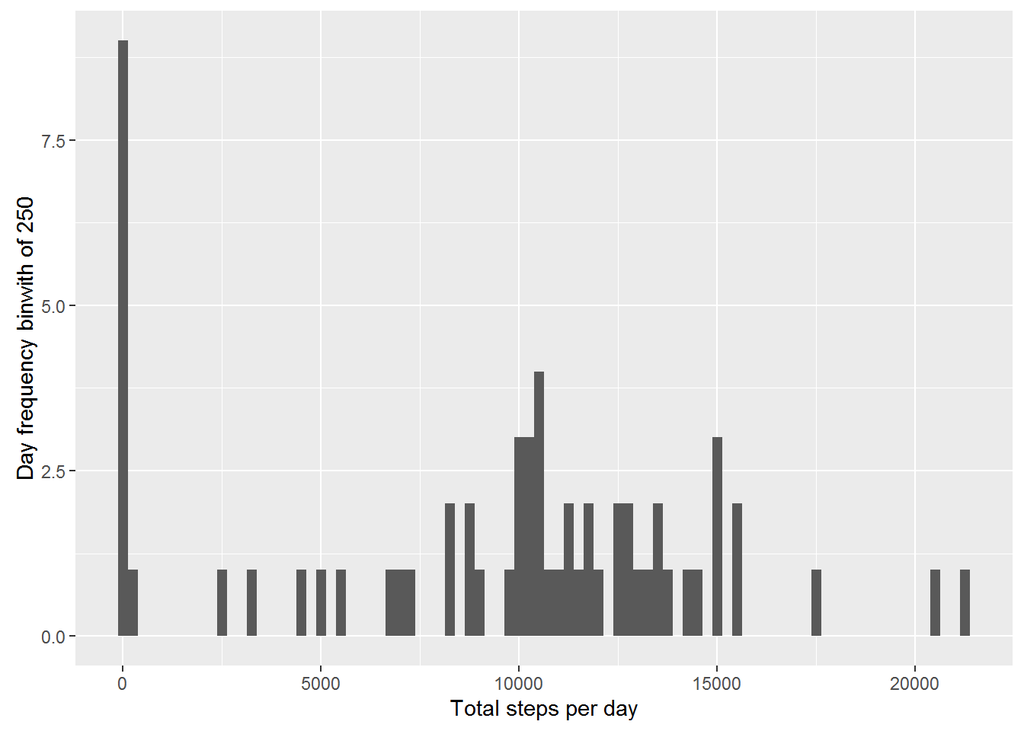

```r
qplot(steps_per_day, xlab='Total steps per day', ylab='Day frequency binwith of 250', binwidth=250)
```

##### 2. Calculate and report the **mean** and **median** total number of steps taken per day

```r
day_mean <- mean(steps_per_day)
day_median <- median(steps_per_day)
```

- Mean: 9354.2295082
- Median: 10395

## What is the average daily activity pattern?

```r
avg_steps <- aggregate(x=list(mean_steps=activity_data$steps), by=list(interval=activity_data$interval), FUN=mean, na.rm=TRUE)
```

##### 1. Make a time series plot (i.e. `type = "l"`) of the 5-minute interval (x-axis) and the average number of steps taken, averaged across all days (y-axis)

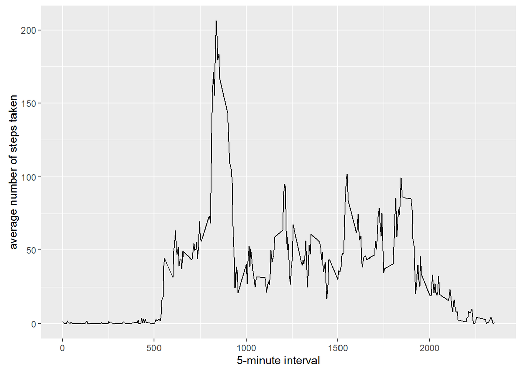

```r
ggplot(data=avg_steps, aes(x=interval, y=mean_steps)) +
    geom_line() +
    xlab("5-minute interval") +
    ylab("average number of steps taken")
```

##### 2. Which 5-minute interval, on average across all the days in the dataset, contains the maximum number of steps?

```r
max_steps <- which.max(avg_steps$mean_steps)
```

- Most Steps at interval : 835

## Imputing missing values

##### 1. Calculate and report the total number of missing values in the dataset

```r
num_missing_values <- length(which(is.na(activity_data)))
```

- Number of missing values: 2304

##### 3. Create a new dataset that is equal to the original dataset but with the missing data filled in.

```r
activity_data_imputed <- activity_data
activity_data_imputed$steps <- impute(activity_data$steps, fun=  "random")
```

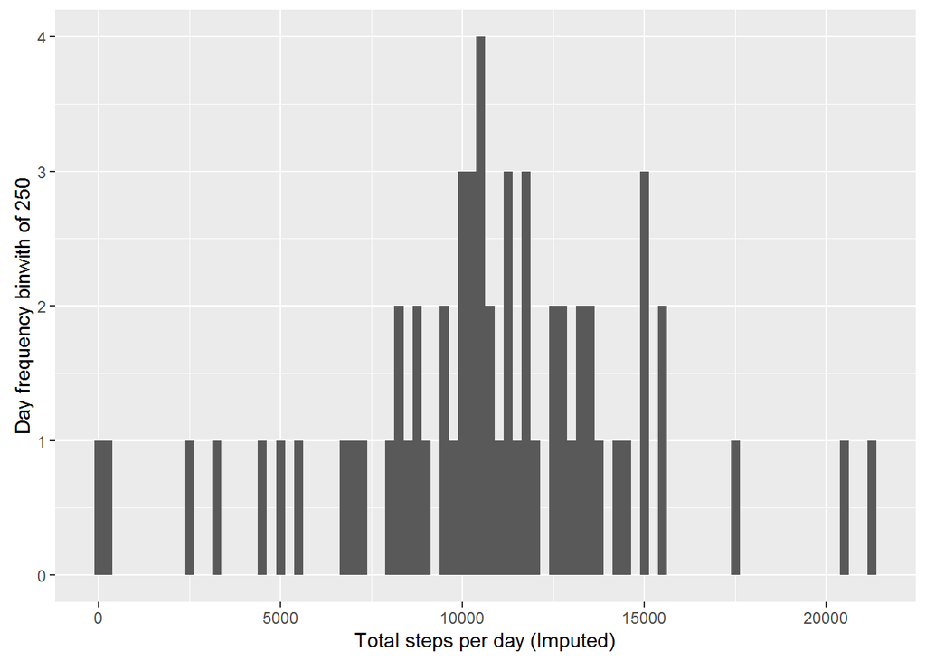

```r
steps_per_day_imputed <- tapply(activity_data_imputed$steps, activity_data_imputed$date, sum)
qplot(steps_per_day_imputed, xlab='Total steps per day (Imputed)', ylab='Day frequency binwith of 250', binwidth=250)
```

```r
steps_per_day_meanimputed <- mean(steps_per_day_imputed)
steps_per_day_medianimputed <- median(steps_per_day_imputed)
```

```r
activity_data_imputed_random <- activity_data
activity_data_imputed_random$steps <- impute(activity_data$steps, fun=  "random")
```

```r
steps_per_day_imputed <- tapply(activity_data_imputed_random$steps, activity_data_imputed_random$date, sum)
```

```r
steps_per_day_meanimputed_random <- mean(steps_per_day_imputed)
steps_per_day_medianimputed_random <- median(steps_per_day_imputed)
```

## Are there differences in activity patterns between weekdays and weekends?

##### 1. Create a new factor variable in the dataset with two levels - “weekday” and “weekend” indicating whether a given date is a weekday or weekend day.

```r
activity_data_imputed$dateType <-  ifelse(as.POSIXlt(activity_data_imputed$date)$wday %in% c(0,6), 'weekend', 'weekday')
```

##### 2. Make a panel plot containing a time series plot (i.e. `type = "l"`) of the 5-minute interval (x-axis) and the average number of steps taken, averaged across all weekday days or weekend days (y-axis)

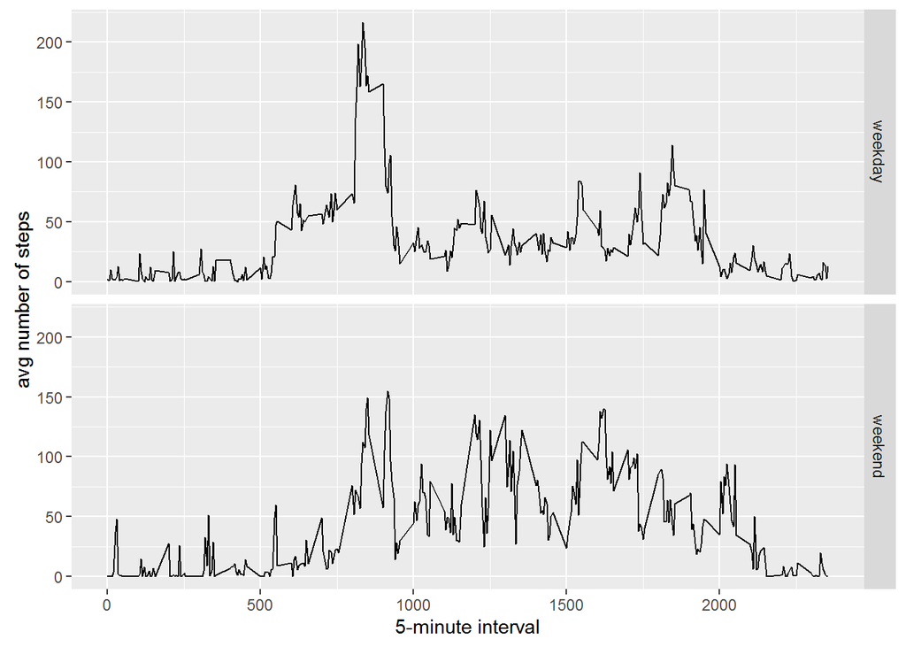

```r
averagedActivity_data_imputed <- aggregate(steps ~ interval + dateType, data=activity_data_imputed, mean)
ggplot(averagedActivity_data_imputed, aes(interval, steps)) +
    geom_line() +
    facet_grid(dateType ~ .) +
    xlab("5-minute interval") +
    ylab("avg number of steps")
```

- Yes, the graph shows qualitatively different behaviors. The weekdays seem more concentrated at peaks whereas the weekends show a wider distribution of the mass. Perhaps this is due to the fact that the weekend provided more occasion for diversity of movement rather than perhaps a mundane routine week.